# Assignment 4

Emily Dale

April 9, 2017

# Case Study: Book Displays at Flourish and Blotts

## Background

The purpose of this analysis is to determine which books should be displayed together at Flourish and Blotts. By examining patterns in previous transactions and association rules, I will be able to make a recommendation to the manager of the bookstore on an ideal book display.

# Data Preparation

### Bring in Data

The data is brought into the environment. Duplicates (for example, one customer buying multiple copies of the same book) are removed.

```r
knitr::opts_knit$set(root.dir = 'C:/Users/eaust/OneDrive/Documents/R/Week4/ADMWeek4/data')
```

```r
library(arules)
bookbaskets <- read.transactions("bookdata.tsv.gz", format="single",
                                 sep="\t",
                                 cols=c("userid", "title"),
                                 rm.duplicates=T)
```

```
## distribution of transactions with duplicates:
## items
##   1   2   3   4   5   6   7   8   9  10  11  12  13  14  15  16  17  18
## 701 222 106  68  43  39  23  24  18  18  16  10   7   7  13   7   8   5
##  19  20  21  22  23  25  26  27  28  29  30  31  33  34  35  38  39  42
##   3   9   4   4   3   2   2   5   4   5   4   4   1   2   1   1   1   2
##  44  45  47  48  49  52  56  57  59  61  63  71  73  80  84  86  91  93
##   1   1   1   1   1   1   2   1   2   1   2   1   1   1   1   1   1   1
##  95  96  99 103 158 206 260 891
##   1   1   1   1   1   2   1   1
```

The distribution of these transactions seems suspect. 1 customer purchased 891 books, 1 purchased 260, and 2 purchased 206. These IDs may not be accurate, and may instead be guest IDs, online orders, employee IDs, etc. As these large purchases may skew the data, I have decided to remove orders with more than 200 purchases. Since we are studying association rules, baskets with only 1 book should also be removed.

```r
basketSizes<-size(bookbaskets)
bookbasket_use<-bookbaskets[basketSizes>1 & basketSizes < 200]
```

Next, I examine the data. I first look at the first five transactions and the size and frequency of all transactions. Next I get the count of the total number of books purchased and remove any transactions where only one book was purchased.

```r
inspect(bookbasket_use[1:5])
```

```
##     items                                                                                           transactionID
## [1] {Chicken Soup for the Teenage Soul on Tough Stuff : Stories of Tough Times and Lessons Learned,
##      Dragon Ball Z, Vol. 1,
##      Harry Potter and the Chamber of Secrets,
##      Harry Potter and the Sorcerer's Stone,
##      Holes,
##      Prey,
##      Primary Colors: A Novel of Politics,
##      Rising Sun,
##      The Cat Who Smelled a Rat,
##      The Fellowship of the Ring,
##      The Hunt for Red October,
##      The Return of the King,
##      The Two Towers}                                                                                       100004
## [2] {Blood and Money,
##      Dancing Girls: And Other Stories,
##      Day of Two Sunsets: Paddling Adventures on Canada's West Coast,
##      Disclosure,
##      Downsize This! Random Threats from an Unarmed American,
##      Dragon,
##      Dune,
##      Flesh and Blood,
##      Footprints of Thunder,
##      From the Corner of His Eye,
##      G Is for Gumshoe,
##      Ghost Stories of British Columbia,
##      Hannibal,
##      Hearts In Atlantis,
##      Illustrated History of British Columbia,
##      Madonna: An Intimate Biography,
##      Patriot Games,
##      Perfect Evil,
##      Pet Sematary,
##      Point Of Impact,
##      Relic,
##      Riptide,
##      Robert Ludlum's The Cassandra Compact,
##      Robert Ludlum's The Paris Option : A Covert-One Novel,
##      Stupid White Men ...and Other Sorry Excuses for the State of the Nation!,
##      TENDER IS THE NIGHT,
```

[output cut: 39 more lines]

```
##      Autumn of the Gun,
##      Cry to Heaven,
##      Dance While You Can,
##      Pandora's Box,
##      Rogue Warrior,
##      Tea Planter's Bride,
##      The Border Empire,
##      The Dawn of Fury,
##      The Killing Season,
##      You'll Never Eat Lunch in This Town Again}                                                            100010
## [5] {Die Korrekturen.,
##      Logic,
##      River God,
##      Shaman Winter,
##      The Cassandra Compact : International Edition}                                                        100029
```

```r
basketSizes<-size(bookbasket_use)
bookFreq<-itemFrequency(bookbasket_use)


bookCount <- (bookFreq/sum(bookFreq))*sum(basketSizes)
```

# Examining the Transactions

First, I will calculate the support, or frequency, of the books. I first put the frequency in a dataframe.

```r
freq_book_data_frame <- as.data.frame(itemFrequency(bookbasket_use))
#View(freq_book_data_frame)
```

### Best Sellers

By looking at the frequency of books purchased, I can get a better picture of the books that are best sellers. Let’s look at the top 10 best sellers.

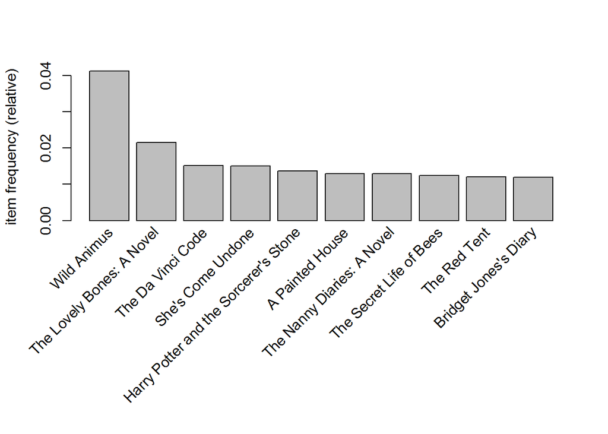

```r
itemFrequencyPlot(bookbasket_use, topN=10)
```

# Association Rules Algorithm

Next I will begin examining assocation rules of these transactions using the apriori algorithm. This algorithm uses the “bottom up” approach: it looks for the most frequent items first, then looks for the most frequent pairs of items, then triplets, etc. It will generate rules based on these frequencies.

### Parameter settings

The default settings for apriori are support= 0.1 (frequency of 10%), confidence = 0.8 (rule is correct 80% of the time), max length = 10 (max number of items in a list is 10), and min length = 1 (minimum number of items in a list is 1). As we saw in the previous plots, none of the books appeared in more than 4% of purchases, so the default settings for this algorithm will yield zero results. Let’s try it to verify.

```r
bookbaskets_noAnimus <- apriori(bookbaskets,appearance = list(none = c("Wild Animus")))
```

```
## Apriori
##
## Parameter specification:
##  confidence minval smax arem  aval originalSupport maxtime support minlen
##         0.8    0.1    1 none FALSE            TRUE       5     0.1      1
##  maxlen target   ext
##      10  rules FALSE
##
## Algorithmic control:
##  filter tree heap memopt load sort verbose
##     0.1 TRUE TRUE  FALSE TRUE    2    TRUE
##
## Absolute minimum support count: 9210
##
## set item appearances ...[1 item(s)] done [0.00s].
## set transactions ...[220447 item(s), 92108 transaction(s)] done [0.63s].
## sorting and recoding items ... [0 item(s)] done [0.05s].
## creating transaction tree ... done [0.00s].
## checking subsets of size 1 done [0.00s].
## writing ... [0 rule(s)] done [0.00s].
## creating S4 object  ... done [0.06s].
```

As suspected, there are no rules available.

Next, let’s try with different parameters. I would like to see rules that involve books with support of 1%, confidence of 70%, and will leave min and max the same for now. Again, “Wild Animus” is excluded.

```r
apriori(bookbasket_use, parameter = list(support =0.01, confidence = 0.7), appearance = list(none = c("Wild Animus")))
```

```
## Apriori
##
## Parameter specification:
##  confidence minval smax arem  aval originalSupport maxtime support minlen
##         0.7    0.1    1 none FALSE            TRUE       5    0.01      1
##  maxlen target   ext
##      10  rules FALSE
##
## Algorithmic control:
##  filter tree heap memopt load sort verbose
##     0.1 TRUE TRUE  FALSE TRUE    2    TRUE
##
## Absolute minimum support count: 400
##
## set item appearances ...[1 item(s)] done [0.00s].
## set transactions ...[142363 item(s), 40011 transaction(s)] done [0.28s].
## sorting and recoding items ... [15 item(s)] done [0.03s].
## creating transaction tree ... done [0.00s].
## checking subsets of size 1 2 done [0.00s].
## writing ... [0 rule(s)] done [0.00s].
## creating S4 object  ... done [0.00s].
```

```
## set of 0 rules
```

Unfortunately, there are still no rules. I will again lower the minimum standards. I will now look at rules that have books with .1% support, 80% confidence, and a minimum length of 3.

```r
book_rules <- apriori(bookbasket_use, parameter = list(support =0.001, confidence = 0.80, minlen = 3), appearance = list(none = c("Wild Animus")))
```

```
## Apriori
##
## Parameter specification:
##  confidence minval smax arem  aval originalSupport maxtime support minlen
##         0.8    0.1    1 none FALSE            TRUE       5   0.001      3
##  maxlen target   ext
##      10  rules FALSE
##
## Algorithmic control:
##  filter tree heap memopt load sort verbose
##     0.1 TRUE TRUE  FALSE TRUE    2    TRUE
##
## Absolute minimum support count: 40
##
## set item appearances ...[1 item(s)] done [0.00s].
## set transactions ...[142363 item(s), 40011 transaction(s)] done [0.30s].
## sorting and recoding items ... [1471 item(s)] done [0.03s].
## creating transaction tree ... done [0.02s].
## checking subsets of size 1 2 3 4 5 done [0.02s].
## writing ... [94 rule(s)] done [0.00s].
## creating S4 object  ... done [0.03s].
```

```r
print(book_rules)
```

```
## set of 94 rules
```

94 rules were created! Let’s start examining the rules.

# Rules

```r
summary(book_rules)
```

```
## set of 94 rules
##
## rule length distribution (lhs + rhs):sizes
##  3  4  5
## 60 30  4
##
##    Min. 1st Qu.  Median    Mean 3rd Qu.    Max.
##   3.000   3.000   3.000   3.404   4.000   5.000
##
## summary of quality measures:
##     support           confidence          lift
##  Min.   :0.001025   Min.   :0.8025   Min.   : 60.34
##  1st Qu.:0.001075   1st Qu.:0.8538   1st Qu.:122.08
##  Median :0.001200   Median :0.9008   Median :243.85
##  Mean   :0.001492   Mean   :0.8959   Mean   :249.89
##  3rd Qu.:0.001643   3rd Qu.:0.9375   3rd Qu.:337.61
##  Max.   :0.003574   Max.   :1.0000   Max.   :575.61
##
## mining info:
##            data ntransactions support confidence
##  bookbasket_use         40011   0.001        0.8
```

- This summary shows basic information about the 94 rules:
- 60 rules have 3 items each
- 30 rules have 4 items each
- 4 rules have 5 items each
- Support ranges from .1% to .36%
- Confidence ranges from 80% to 100%. We should look at the rules with 100% confidence.
- Lift (more on that below) ranges from 60-575.

### More on Lift

```r
bookrules_liftsort <- sort(book_rules, by = "lift")
inspect(bookrules_liftsort[1:5])
```

```
##     lhs                                                               rhs                                        support confidence     lift
## [1] {Apollyon: The Destroyer Is Unleashed,
##      Nicolae: The Rise of Antichrist,
##      Tribulation Force: The Continuing Drama of Those Left Behind} => {Soul Harvest: The World Takes Sides}  0.001124691  0.9782609 575.6058
## [2] {Apollyon: The Destroyer Is Unleashed,
##      Nicolae: The Rise of Antichrist}                              => {Soul Harvest: The World Takes Sides}  0.001149684  0.9583333 563.8805
## [3] {Apollyon: The Destroyer Is Unleashed,
##      Left Behind: A Novel of the Earth's Last Days,
##      Tribulation Force: The Continuing Drama of Those Left Behind} => {Soul Harvest: The World Takes Sides}  0.001024718  0.9318182 548.2791
## [4] {Apollyon: The Destroyer Is Unleashed,
##      Tribulation Force: The Continuing Drama of Those Left Behind} => {Soul Harvest: The World Takes Sides}  0.001199670  0.9230769 543.1357
## [5] {Nicolae: The Rise of Antichrist,
##      Soul Harvest: The World Takes Sides,
##      Tribulation Force: The Continuing Drama of Those Left Behind} => {Apollyon: The Destroyer Is Unleashed} 0.001124691  0.9375000 535.8616
```

These rules, while high in lift, are not particularly interesting as they are all part of the “Left Behind” series. As the manager has stated, my recommendation shouldn’t include books in a series, as it’s a given that they should be displayed together.

Next, let’s inspect the rules by their support.

```r
bookrules_supportsort <- sort(book_rules, by = "support")
inspect(bookrules_supportsort[1:5])
```

```
##     lhs                                           rhs                                            support confidence      lift
## [1] {Harry Potter and the Chamber of Secrets,
##      Harry Potter and the Prisoner of Azkaban} => {Harry Potter and the Sorcerer's Stone}    0.003574017  0.8218391  60.33505
## [2] {Harry Potter and the Prisoner of Azkaban,
##      Harry Potter and the Sorcerer's Stone}    => {Harry Potter and the Chamber of Secrets}  0.003574017  0.8993711  97.78461
## [3] {Harry Potter and the Goblet of Fire,
##      Harry Potter and the Prisoner of Azkaban} => {Harry Potter and the Chamber of Secrets}  0.003299093  0.8571429  93.19332
## [4] {Harry Potter and the Chamber of Secrets,
##      Harry Potter and the Goblet of Fire}      => {Harry Potter and the Prisoner of Azkaban} 0.003299093  0.9041096 126.92747
## [5] {Harry Potter and the Chamber of Secrets,
##      Harry Potter and the Goblet of Fire}      => {Harry Potter and the Sorcerer's Stone}    0.002999175  0.8219178  60.34083
```

Again, these are all part of a series of books by J.K. Rowling. While these should be of particular interest to Flourish and Blotts given their subject matter, these rules should not be in the recommendation.

Next, let’s look at rules sorted by confidence.

```r
bookrules_consort <- sort(book_rules, by = "confidence")
inspect(bookrules_consort[1:5])
```

```
##     lhs                                                               rhs                                                                support confidence     lift
## [1] {Left Behind: A Novel of the Earth's Last Days,
##      Nicolae: The Rise of Antichrist,
##      Soul Harvest: The World Takes Sides}                          => {Tribulation Force: The Continuing Drama of Those Left Behind} 0.001024718  1.0000000 354.0796
## [2] {Harry Potter and the Chamber of Secrets,
##      Harry Potter and the Goblet of Fire,
##      Harry Potter and the Order of the Phoenix,
##      Harry Potter and the Sorcerer's Stone}                        => {Harry Potter and the Prisoner of Azkaban}                     0.001499588  0.9836066 138.0880
## [3] {Apollyon: The Destroyer Is Unleashed,
##      Nicolae: The Rise of Antichrist,
##      Soul Harvest: The World Takes Sides}                          => {Tribulation Force: The Continuing Drama of Those Left Behind} 0.001124691  0.9782609 346.3823
## [4] {Apollyon: The Destroyer Is Unleashed,
##      Nicolae: The Rise of Antichrist,
##      Tribulation Force: The Continuing Drama of Those Left Behind} => {Soul Harvest: The World Takes Sides}                          0.001124691  0.9782609 575.6058
## [5] {Four to Score,
##      High Five,
##      Two for the Dough}                                            => {Three To Get Deadly : A Stephanie Plum Novel}                 0.001074704  0.9772727 298.4859
```

Since these are again all parts of series, this is also not of interest. The goal is to maximize confidence, lift, and support in books that are not part of a series.

After further inspection, every one of these 94 rules involves series. This is not what the manager will want to see! I will now go back and come up with the rules again, but this time I will exclude the rules involving series by manually looking at the rules.

```r
book_rules3 <- apriori(bookbasket_use, parameter = list(support =0.0005, confidence = 0.75, minlen = 3), appearance = list(none = c("Wild Animus")))
```

```
## Apriori
##
## Parameter specification:
##  confidence minval smax arem  aval originalSupport maxtime support minlen
##        0.75    0.1    1 none FALSE            TRUE       5   5e-04      3
##  maxlen target   ext
##      10  rules FALSE
##
## Algorithmic control:
##  filter tree heap memopt load sort verbose
##     0.1 TRUE TRUE  FALSE TRUE    2    TRUE
##
## Absolute minimum support count: 20
##
## set item appearances ...[1 item(s)] done [0.00s].
## set transactions ...[142363 item(s), 40011 transaction(s)] done [0.28s].
## sorting and recoding items ... [3294 item(s)] done [0.01s].
## creating transaction tree ... done [0.02s].
## checking subsets of size 1 2 3 4 5 6 7 done [0.09s].
## writing ... [1330 rule(s)] done [0.00s].
## creating S4 object  ... done [0.03s].
```

```r
print(book_rules3)
```

```
## set of 1330 rules
```

# Rules Analysis

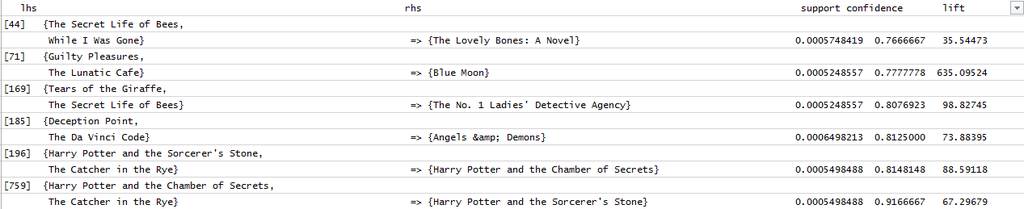

Examining Rules

- After going through the 1330 rules, I was able to find rules that didn’t exclusively include series:
- Harry Potter and the Lord of the Rings: while these are both series, customers who purchased books from one series were more likely to also purchase books from the other. These series should be displayed together for maximum exposure.
- The Catcher in the Rye also had an assocation with the Harry Potter series, specifically the first two books. Customers who purchased The Catcher in the Rye and either the first or second HP book respectivally were more likely to purchase the second or first Harry Potter book respectivally.
- When displayed with the Vampire Hunter series by Laurell Hamilton, we can expect Blue Moon to have 635 times more likelihood of being purchased. A great way to display this is by having a “If you liked the Vampire Hunter Series, you’ll love this!” type of display set up to advertise Blue Moon. They are both science fiction books involving immortals, so it makes sense that readers of one would like the other.
- While not exactly a series, Dan Brown novels should be displayed together.
- 77% of customers who purchased The Secret Life of Bees and While I was Gone (two popular novels) also purchased The Lovely Bones, also a popular novel. All three are also popular book club books.

# Book Clubs

I will first inspect the top ten books by support.

```r
bookclub = apriori(bookbasket_use,
                        parameter = list(
                          support = 0.0001,
                          confidence = 0.85,
                          minlen = 2,
                          maxlen = 10
                          ),
                        appearance = list(lhs =
                                            c("The Lovely Bones: A Novel",
                                  "She's Come Undone",
                                  "The Secret Life of Bees",
                                  "White Oleander : A Novel",
                                  "Girl with a Pearl Earring",
                                  "Where The Heart Is",
                                  "The Joy Luck Club",
                                  "The Pilot's Wife : A Novel",
                                  "I Know This Much Is True",
                                  "While I Was Gone",
                                  "Stones From the River",
                                  "Jewel",
                                  "The Deep End of the Ocean",
                                  "A Map of the World",
                                  "Here On Earth",
                                  "Black and Blue",
                                  "Love in the Time of Cholera",
                                  "Vinegar Hill",
                                  "Songs in Ordinary Time",
                                  "A Lesson Before Dying",
                                  "The Rapture of Canaan",
                                  "East of Eden",
                                  "Night",
                                  "Ruby",
                                  "The Witness for the Prosecution and Other Stories",
                                  "White Oleander"), default = "rhs")
)
```

```
## Apriori
##
## Parameter specification:
##  confidence minval smax arem  aval originalSupport maxtime support minlen
##        0.85    0.1    1 none FALSE            TRUE       5   1e-04      2
##  maxlen target   ext
##      10  rules FALSE
##
## Algorithmic control:
##  filter tree heap memopt load sort verbose
##     0.1 TRUE TRUE  FALSE TRUE    2    TRUE
##
## Absolute minimum support count: 4
##
## set item appearances ...[26 item(s)] done [0.00s].
## set transactions ...[142363 item(s), 40011 transaction(s)] done [0.27s].
## sorting and recoding items ... [18142 item(s)] done [0.03s].
## creating transaction tree ... done [0.02s].
## checking subsets of size 1 2 3 4 5 6 7 8 done [0.73s].
## writing ... [289 rule(s)] done [0.16s].
## creating S4 object  ... done [0.06s].
```

```r
bookclub_sorted <- sort(bookclub, by = "support")
inspect(bookclub_sorted[1:10])
```

```
##      lhs                            rhs                                  support confidence     lift
## [1]  {She's Come Undone,
##       The Lovely Bones: A Novel,
##       Where The Heart Is,
##       While I Was Gone}          => {The Reader}                    0.0002249381  0.9000000 126.3505
## [2]  {She's Come Undone,
##       The Lovely Bones: A Novel,
##       While I Was Gone,
##       White Oleander : A Novel}  => {The Reader}                    0.0002249381  0.9000000 126.3505
## [3]  {I Know This Much Is True,
##       Songs in Ordinary Time,
##       Vinegar Hill}              => {The Reader}                    0.0001999450  0.8888889 124.7906
## [4]  {Songs in Ordinary Time,
##       The Lovely Bones: A Novel,
##       While I Was Gone}          => {Drowning Ruth}                 0.0001999450  0.8888889 163.1437
## [5]  {I Know This Much Is True,
##       While I Was Gone,
##       White Oleander : A Novel}  => {The Reader}                    0.0001999450  0.8888889 124.7906
## [6]  {I Know This Much Is True,
##       The Secret Life of Bees,
##       While I Was Gone}          => {The Reader}                    0.0001999450  0.8888889 124.7906
## [7]  {I Know This Much Is True,
##       Where The Heart Is,
##       White Oleander : A Novel}  => {The Reader}                    0.0001999450  0.8888889 124.7906
## [8]  {I Know This Much Is True,
##       She's Come Undone,
##       The Lovely Bones: A Novel,
##       While I Was Gone}          => {The Reader}                    0.0001999450  0.8888889 124.7906
## [9]  {Jewel,
##       She's Come Undone,
##       Songs in Ordinary Time}    => {The Reader}                    0.0001749519  0.8750000 122.8408
## [10] {Songs in Ordinary Time,
##       Where The Heart Is,
##       White Oleander : A Novel}  => {The Poisonwood Bible: A Novel} 0.0001749519  0.8750000 114.0379
```

It looks like The Reader, Drowning Ruth, and The Poisonwood Bible are all popular choices with customers who have purchased book club novels.

Now, let’s look at confidence.

```r
bookclub_sorted2 <- sort(bookclub, by = "confidence")
inspect(bookclub_sorted2[1:10])
```

```
##      lhs                             rhs                                  support confidence     lift
## [1]  {Songs in Ordinary Time,
##       The Secret Life of Bees,
##       Vinegar Hill}               => {The Reader}                    0.0001249656          1 140.3895
## [2]  {Here On Earth,
##       She's Come Undone,
##       Songs in Ordinary Time}     => {Drowning Ruth}                 0.0001249656          1 183.5367
## [3]  {A Map of the World,
##       Jewel,
##       Songs in Ordinary Time}     => {The Reader}                    0.0001499588          1 140.3895
## [4]  {Black and Blue,
##       Jewel,
##       Songs in Ordinary Time}     => {Drowning Ruth}                 0.0001499588          1 183.5367
## [5]  {Black and Blue,
##       I Know This Much Is True,
##       Songs in Ordinary Time}     => {The Reader}                    0.0001249656          1 140.3895
## [6]  {Songs in Ordinary Time,
##       The Secret Life of Bees,
##       While I Was Gone}           => {The Reader}                    0.0001499588          1 140.3895
## [7]  {The Pilot's Wife : A Novel,
##       The Rapture of Canaan,
##       Vinegar Hill}               => {Drowning Ruth}                 0.0001249656          1 183.5367
## [8]  {A Map of the World,
##       The Rapture of Canaan,
##       Where The Heart Is}         => {The Poisonwood Bible: A Novel} 0.0001249656          1 130.3290
## [9]  {Black and Blue,
##       The Pilot's Wife : A Novel,
##       The Rapture of Canaan}      => {House of Sand and Fog}         0.0001249656          1 112.0756
## [10] {A Lesson Before Dying,
##       Here On Earth,
##       Vinegar Hill}               => {The Reader}                    0.0001249656          1 140.3895
```

Again, The Reader, Drowning Ruth, and The Poisonwood Bible are popular choices, in addition to House of Sand and Fog.

Finally, I will look at lift.

```r
bookclub_sorted3 <- sort(bookclub, by = "lift")
inspect(bookclub_sorted3[1:10])
```

```
##      lhs                             rhs                                       support confidence     lift
## [1]  {I Know This Much Is True,
##       The Secret Life of Bees,
##       Vinegar Hill}               => {Gap Creek: The Story Of A Marriage} 0.0001499588  0.8571429 263.8088
## [2]  {A Map of the World,
##       Jewel,
##       She's Come Undone,
##       The Rapture of Canaan}      => {Icy Sparks}                         0.0001249656  1.0000000 221.0552
## [3]  {Here On Earth,
##       The Pilot's Wife : A Novel,
##       Vinegar Hill}               => {The Book of Ruth}                   0.0001249656  1.0000000 198.0743
## [4]  {Here On Earth,
##       Jewel,
##       The Pilot's Wife : A Novel} => {The Book of Ruth}                   0.0001249656  1.0000000 198.0743
## [5]  {Black and Blue,
##       Here On Earth,
##       The Pilot's Wife : A Novel} => {The Book of Ruth}                   0.0001249656  1.0000000 198.0743
## [6]  {Here On Earth,
##       Jewel,
##       Songs in Ordinary Time,
##       Where The Heart Is}         => {The Book of Ruth}                   0.0001249656  1.0000000 198.0743
## [7]  {Here On Earth,
##       Jewel,
##       The Rapture of Canaan,
##       Where The Heart Is}         => {The Book of Ruth}                   0.0001249656  1.0000000 198.0743
## [8]  {Jewel,
##       The Rapture of Canaan,
##       Where The Heart Is,
##       White Oleander : A Novel}   => {The Book of Ruth}                   0.0001249656  1.0000000 198.0743
## [9]  {Here On Earth,
##       Jewel,
##       Vinegar Hill,
##       Where The Heart Is}         => {The Book of Ruth}                   0.0001249656  1.0000000 198.0743
## [10] {Here On Earth,
##       Jewel,
##       Where The Heart Is,
##       While I Was Gone}           => {The Book of Ruth}                   0.0001249656  1.0000000 198.0743
```

Gap Creek: The Story of A Marriage tops the list, followed by Icy Sparks and a string of The Book of Ruth.

# Book Club Recommendations

I highly recommend displaying the most popular book club novels: The Lovely Bones, She’s Come Undone, The Secret Life of Bees, WHile I Was Gone, White Oleander, Where The Heart Is, and Jewel. In addition, I would display The Reader, Drowning Ruth, The Poisonwood Bible, and The Book of Ruth close to the above books to appeal to the customers that read book club novels.

# Final Recommendations

*Here is a summary of all recommendations for Flourish and Blotts for the summer season: +Display the Harry Potter and Lord of the Rings near each other to advertise to customers that may be interested in both. +Catcher in the Rye should be close to Harry Potter. +Create a “If you liked that, you’ll love this!” display for the Vampire Hunter series and Blue Moon. +The Lovely Bones, She’s Come Undone, The Secret Life of Bees, WHile I Was Gone, White Oleander, Where The Heart Is, and Jewel should all be displayed near the front of the store together to appeal to book club members. The Reader, Drowning Ruth, The Poisonwood Bible, and The Book of Ruth should be scattered throughout the book club display to appeal to that customer segment.